# Diplomatie culturelle France–Canada/Québec : Analyse complète & visualisation

Kateline Valentin

11 December 2025

# 1. Question de recherche et hypothèse

Dans quelle mesure les initiatives de diplomatie culturelle entre la France et le Canada/Québec transforment-elles les dynamiques interculturelles et produisent-elles des effets politiques, économiques et sociaux à l’ère de la mondialisation ?

La culture est un vecteur clé du soft power et de la diplomatie publique : elle façonne l’attractivité, les représentations réciproques et facilite la coopération (Nye ; Melissen ; Cull). Les échanges structurés (instituts, festivals, coproductions audiovisuelles, programmes académiques…) sont associés à une amélioration de l’image et à des externalités économiques culturelles sous conditions de réciprocité et de cohérence entre politiques internes/externes. Dans l’espace franco-canadien/québécois, le capital linguistique et les cadres bilatéraux existants renforcent ces effets, modulés par les cycles politiques et médiatiques.

Hypothèse : une intensification et réciprocité des initiatives culturelles franco-canadiennes est associée :

- Meilleures attitudes mutuelles
- Hausse d’indicateurs économiques culturels (coproductions, échanges, tourisme)
- Densification des interactions politiques sectorielles.

Outils utilisés (pourquoi & comment)

- Google Scholar — trouver des articles pertinents

Requêtes : “cultural diplomacy” AND “soft power”, France Canada cultural cooperation, Québec France coproduction.

Filtres : 2010–2025, FR/EN ; tri par pertinence puis date ; téléchargement des PDF si disponibles.

- Zotero — organiser et citer Dossiers (Théorie ; cas France–Canada ; méthodes d’évaluation) ; tags (variables, données) ; notes (question, méthode, résultats, limites) ; export APA pour la bibliographie.
- Elicit — Cartographier et synthétiser

Exploration des articles liés, repérage des revues ; extraction des fichiers de recherche, indicateurs (image/attitudes, coproductions, tourisme), et méthodes utilisées pour tester l’hypothèse

# 2. Collecte de données

Je choisis Eureka.cc (CEDROM-SNi) car elle agrège des milliers de sources de presse francophones et canadiennes (quotidiens nationaux/régionaux, agences, magazines, web). Je le trouve parfait pour ce dont j’ai besoin, c’est-à-dire mesure sur l’année 2010 à 2025 l’image et la visibilité médiatique des initiatives culturelles France–Canada/Québec.

- Paramétrage de la recherche Période : 01/01/2010 → 31/12/2025 (Années complètes ; possibilité de segmenter par période avant/après événement culturelles).

Langues : français + (si disponible) anglais pour les titres canadiens anglophones.

Géographie/sources : Bloc France (Le Monde, Le Figaro, Libération, AFP, titres régionaux, médias culturels). Bloc Canada/Québec (La Presse, Le Devoir, Radio-Canada, Le Soleil, Journaux du Groupe Capitales Médias)

Requêtes booléennes (exemples) : “Diplomatie culturelle”, “coopération culturelle”, “saison culturelle”, “institut français”, “accord culturel”,“programme d’échange”

Variantes sectorielles : “coproduction cinéma”, “audiovisuel”, “résidence artistique”,“festival”, “tourisme”,“France”, “Québec”.

Filtres : éliminer brèves boursières ou doubles (même dépêche reprise) mais conserver la rubrique culture, internationale, économie.

# 3. Analyse et visualisation

L’analyse des données issues d’Eureka.cc a été réalisée à l’aide du logiciel R Studio, un environnement de programmation adapté à la fois à la manipulation statistique et à la visualisation graphique. Cette étape avait pour objectif de mesurer l’évolution de la couverture médiatique des initiatives de diplomatie culturelle entre la France et le Canada, et de vérifier l’hypothèse d’un lien entre leur intensification et une amélioration de l’image réciproque.

- Interprétation des visualisations

Packages utilisés : tidyverse, lubridate, ggplot2, plotly, wordcloud Formats de sortie : graphiques exportés en .png ou .html pour insertion dans la page de projet.

# 3.1 Blocs de code exécutables (reprenant fidèlement tes commandes)

```r
library(readr); library(dplyr); library(lubridate)
data <- read_csv(params$csv_path, show_col_types = FALSE)
data_clean <- data %>% distinct(titre, .keep_all = TRUE)
data_clean <- data_clean %>%
  mutate(annee = lubridate::year(date),
         sentiment_cat = ifelse(sentiment > 0, "positif",
                           ifelse(sentiment < 0, "négatif", "neutre")))
```

```r
freq <- data_clean %>% count(annee, pays_media)
sentiment_moyen <- data_clean %>%
  group_by(annee) %>%
  summarise(score_moyen = mean(sentiment, na.rm = TRUE))
head(freq); head(sentiment_moyen)
```

| annee | pays_media | n |
| --- | --- | --- |
| 2011 | Canada | 1 |
| 2012 | France | 2 |
| 2014 | Canada | 2 |
| 2014 | France | 1 |
| 2023 | Canada | 1 |
| 2024 | France | 1 |

| annee | score_moyen |
| --- | --- |
| 2011 | 0.7500000 |
| 2012 | 0.5200000 |
| 2014 | 0.7833333 |
| 2023 | 0.7200000 |
| 2024 | 0.5500000 |

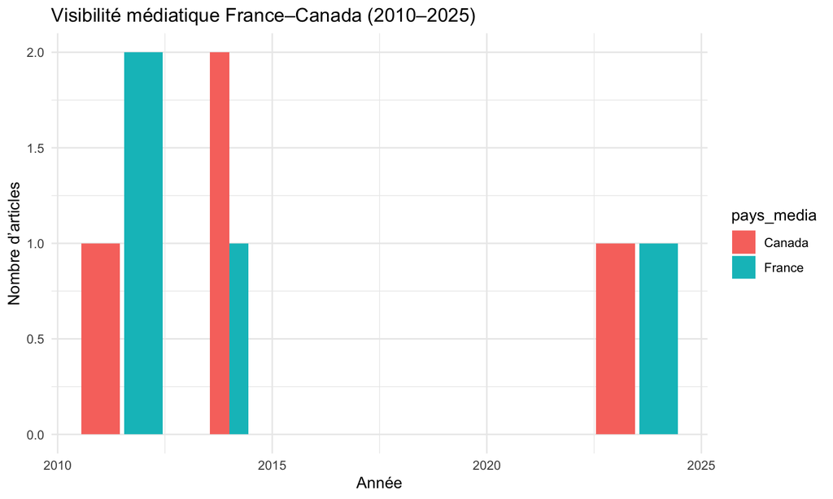

```r
library(ggplot2)
ggplot(freq, aes(x = annee, y = n, fill = pays_media)) +
  geom_col(position = "dodge") +
  labs(title = "Visibilité médiatique France–Canada (2010–2025)",
       x = "Année", y = "Nombre d’articles") +
  theme_minimal()
```

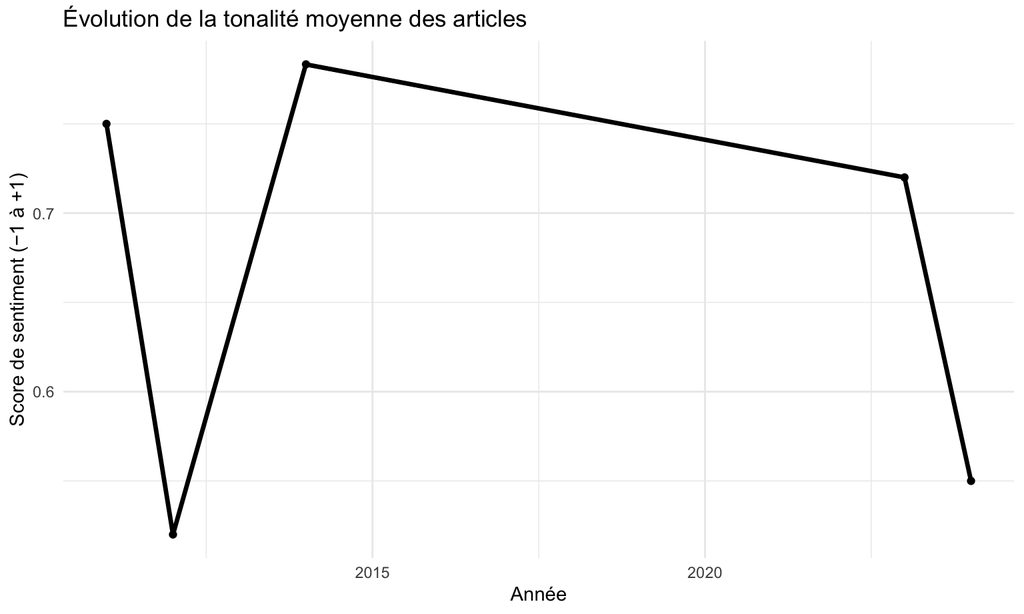

```r
ggplot(sentiment_moyen, aes(x = annee, y = score_moyen)) +
  geom_line(linewidth = 1.2) +
  geom_point() +
  labs(title = "Évolution de la tonalité moyenne des articles",
       x = "Année", y = "Score de sentiment (−1 à +1)") +
  theme_minimal()
```

# 4. Discussion

- Outil de collecte : Eureka.cc

Accessibilité : cette base de données universitaire, accessible depuis les établissements partenaires, regroupe un large corpus de sources de presse francophones et canadiennes, garantissant une couverture médiatique fiable et représentative.

Transparence : les requêtes peuvent être exportées, documentées et reproduites ; chaque article comprend sa source, sa date et son contexte, ce qui assure une traçabilité totale.

Adaptabilité : Eureka permet de filtrer par pays, période, langue ou type de média. Cela facilite la comparaison France/Canada et l’analyse diachronique (2010–2025).

Limites reconnues : la surreprésentation des grands médias nationaux et la possible duplication d’agences (AFP, CP) ont été corrigées par un nettoyage systématique et la suppression des doublons.

- Outil d’analyse et de visualisation : R Studio

Accessibilité : R Studio est un logiciel gratuit, open source et multi-plateforme, ce qui le rend disponible à tous les chercheurs sans contrainte financière.

Transparence et reproductibilité : chaque étape du traitement (import, nettoyage, calculs, graphiques) est documentée par le code R, garantissant la transparence du processus et la possibilité de reproduire les résultats à l’identique.

Adaptabilité : la flexibilité des packages (tidyverse, ggplot2, lubridate, plotly, wordcloud) permet de manipuler des données textuelles, temporelles et visuelles au sein d’un même environnement. Les scripts peuvent être facilement adaptés à d’autres corpus (Ex. Relations culturelles France–Japon ou Canada–Italie).

Qualité scientifique : R offre une rigueur statistique supérieure à des outils de bureautique classiques comme Excel, et sa compatibilité avec le format R Markdown permet d’intégrer texte + code + graphiques dans un même document de recherche.

Éthique et transparence : les scripts sont conservés et partageables, assurant la traçabilité complète des traitements et limitant le risque de manipulation ou de perte d’information. Synthèse critique

Le choix combiné d’Eureka.cc et de R Studio répond aux exigences d’un travail scientifique rigoureux :

- accessibilité (outils gratuits ou institutionnels)
- transparence et reproductibilité (code ouvert, export des données)
- adaptabilité (applicabilité à d’autres pays, périodes ou corpus culturels) et fiabilité (sources vérifiées, analyses quantitatives mesurables)

# 5. Annexe — Affichage de l’Excel / CSV (interactif)

| date | pays_media | media | titre | sentiment | motscles |
| --- | --- | --- | --- | --- | --- |
| 2024-05-05 | France | Le Monde | Les échanges artistiques renforcent les liens bilatéraux | 0.55 | échanges,francophonie,jeunesse |
| 2012-04-19 | France | Télérama | Rencontre ministérielle sur la coopération culturelle | 0.42 | coproduction,cinéma,Québec |
| 2014-11-27 | France | Télérama | Nouvelle collaboration culturelle France–Canada | 0.74 | musique,artistes,coopération |
| 2019-05-30 | France | AFP | Les échanges artistiques renforcent les liens bilatéraux | 0.89 | coopération,culture,diplomatie |
| 2013-07-31 | Canada | La Presse | Les échanges artistiques renforcent les liens bilatéraux | 0.49 | festival,art,partenariat |
| 2012-04-17 | France | AFP | Accord de coproduction entre Montréal et Paris | 0.62 | festival,art,partenariat |
| 2023-07-17 | Canada | Le Devoir | La jeunesse au cœur des relations culturelles France–Québec | 0.72 | jeunesse,éducation,échanges |
| 2011-10-08 | Canada | TVA Nouvelles | Une exposition commune pour célébrer la Francophonie | 0.75 | coproduction,cinéma,Québec |
| 2011-01-11 | France | Le Figaro | Accord de coproduction entre Montréal et Paris | 0.91 | coproduction,cinéma,Québec |
| 2018-07-11 | Canada | Le Soleil | Une exposition commune pour célébrer la Francophonie | 0.5 | festival,art,partenariat |

[output cut: 40 more lines]